# Demonstration of Regularization

JAS

# Demonstration of Regularization Methods

This will be a demonstration of the three regularization methods discussed: ridge regression, Lasso (least absolute shrinkage and selection operator) and Elastic Net.

## Description of Data

Original data upon which this exercise has been based can be found here: http://www.countyhealthrankings.org/explore-health-rankings/rankings-data-documentation

Variable names are not originally informative. You can look up all full variable name meanings here: http://www.countyhealthrankings.org/sites/default/files/2019%20Analytic%20Documentation_1.pdf

### Load needed libraries

```r
library(tidyverse)
library(caret)
library(glmnet)
```

### Step 1: Read in data, partition, and put features into separate object

When using CreateDataPartition, note that for numeric y, the sample is split into groups sections based on percentiles and sampling is done within these subgroups. This helps training and testing to be similar. Default number of quantiles is 5.

We are partitioning the data in a 70/30 split.

```r
set.seed(100)

chr<-read.csv("C:\\Users\\js5406\\OneDrive - cumc.columbia.edu\\EPIC Course\\chr.csv")

#Strip off ID Variable
chr<-chr[,2:68]

#Add informative feature names
var.names<-c("pre_death", "poorhealth", "poorphyshealth_days", "poormenthealth_days", "low_bwt", "ad_smoking", "ad_obesity", "foodenv_index", "phys_inactivity", "exer_access", "excess_drink", "alc_drivdeaths", "sti", "teen_birth", "uninsured", "primcareproviders", "dentists", "menthealthproviders", "prevhosp", "mammo_screen", "flu_vacc", "hsgrad", "somecollege", "unemployed", "child_poverty", "income_ineq", "sing_parent", "social_assoc", "violent_crime", "injury_deaths", "pm_air", "water_viol", "housing_prob", "driving_alone", "long_commute", "life_exp", "age_adj_premortality", "freq_physdistress", "freq_mentdistress", "diabetes", "hiv", "food_insecure", "ltd_access_healthyfood", "mvcrash_deaths", "insuff_sleep", "uninsured_adults", "uninsured_child", "other_pcp", "medhhinc", "freelunch_child", "res_seg_bw", "res_seg_nw", "firearm_fatalities", "homeownership", "hous_cost_burden", "population", "bw18", "gte65", "nonhisp_afam", "AmerInd_AlasNative", "Asian", "OPacIslander", "Hisp", "nonhisp_white", "nonprof_english", "female", "rural")

colnames(chr)<-var.names


#tidyverse way to create data partition
#training.data<-chr$life_exp %>% createDataPartition(p=0.7, list=F)

train.indices<-createDataPartition(y=chr$life_exp,p=0.7,list=FALSE)
train.data<-chr[train.indices, ]
test.data<-chr[-train.indices, ]

#Store outcome
life.exp.train<-train.data$life_exp
life.exp.test<-test.data$life_exp

#Model.matrix shortcut to removing outcome variable from matrix
x.train<-model.matrix(life_exp~., train.data)[,-1]
x.test<-model.matrix(life_exp~., test.data)[,-1]
```

### Step 2: Running the algorithms on the training data

The glmnet package allows us to run all three of the penalized models using the same format. The value of the alpha parameter dictates whether it is a ride regression, lasso or elastic net. A value of 0 is the ridge regression, the 1 is a lasso and any value in between 0 and 1 will provide an elastic net. The package also takes an input for lambda, but by default it will vary lambda and provide you output for 100 options. There is also an option to use cross-validation to choose the optimal labmda. That requires use of cv.glmnet().

Set standardize to true so all features are on the same scale.

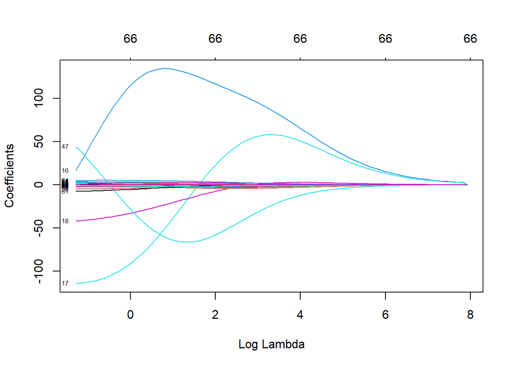

```r
set.seed(100)

#Ridge Regression

model.1<-glmnet(x.train, life.exp.train, alpha=0, standardize = TRUE)

plot(model.1, xvar="lambda", label=TRUE)
```

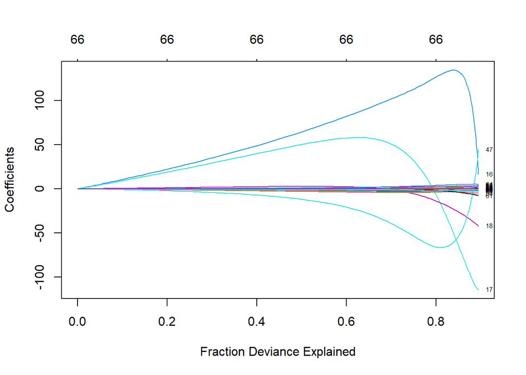

```r
plot(model.1, xvar="dev", label=TRUE)
```

```r
model.1$beta[,1]
```

```
##              pre_death             poorhealth    poorphyshealth_days
##          -1.044641e-39          -4.182733e-35          -2.800615e-36
##    poormenthealth_days                low_bwt             ad_smoking
##          -3.039589e-36          -7.135769e-35          -5.663069e-35
##             ad_obesity          foodenv_index        phys_inactivity
##          -3.524223e-35           1.130179e-36          -3.698144e-35
##            exer_access           excess_drink         alc_drivdeaths
##           4.590675e-36           4.970278e-35           9.883232e-37
##                    sti             teen_birth              uninsured
##          -3.620104e-39          -1.303081e-37          -1.290828e-35
##      primcareproviders               dentists    menthealthproviders
##           2.391599e-33           2.094149e-33           1.463303e-34
##               prevhosp           mammo_screen               flu_vacc
##          -7.035315e-40           1.322887e-35           6.772733e-36
##                 hsgrad            somecollege             unemployed
##           3.311604e-36           1.355549e-35          -7.441631e-35
##          child_poverty            income_ineq            sing_parent
##          -2.161531e-35          -1.395223e-36          -1.371572e-35
##           social_assoc          violent_crime          injury_deaths
##           2.267857e-38          -3.384358e-39          -6.494387e-38
##                 pm_air             water_viol           housing_prob
##          -4.627325e-37           2.440544e-37          -2.670455e-36
##          driving_alone           long_commute   age_adj_premortality
##          -1.219253e-35          -2.302443e-36          -2.530916e-38
##      freq_physdistress      freq_mentdistress               diabetes
##          -8.736439e-35          -1.077930e-34          -7.406201e-35
##                    hiv          food_insecure ltd_access_healthyfood
##          -1.502556e-39          -4.180127e-35          -3.149857e-36
##         mvcrash_deaths           insuff_sleep       uninsured_adults
##          -1.710173e-37          -3.783913e-35          -1.292515e-35
##        uninsured_child              other_pcp               medhhinc
##           4.096762e-36          -1.612955e-34           1.374378e-40
##        freelunch_child             res_seg_bw             res_seg_nw
##          -9.132110e-36           4.298860e-38          -3.255461e-39
##     firearm_fatalities          homeownership       hous_cost_burden
##          -2.284355e-37           1.343661e-36          -2.612396e-37
##             population                   bw18                  gte65
##           2.019381e-43          -1.285647e-35           1.302173e-36
##           nonhisp_afam     AmerInd_AlasNative                  Asian
##          -6.761285e-36          -8.533026e-36           3.157120e-35
##           OPacIslander                   Hisp          nonhisp_white
##           1.248409e-35           3.958457e-36           2.045484e-36
##        nonprof_english                 female                  rural
##           2.595595e-35          -1.593835e-35          -1.884897e-36
```

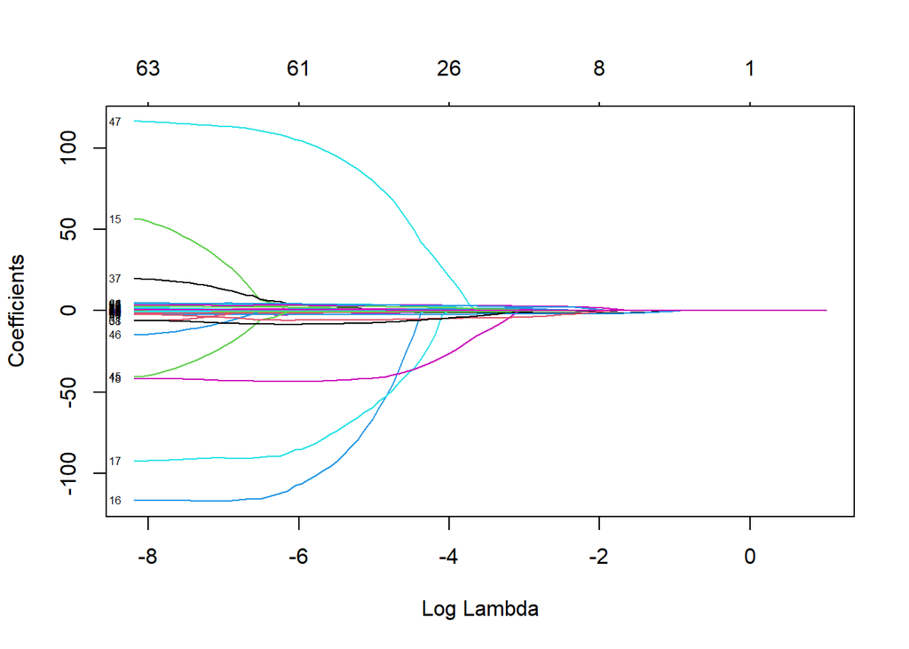

```r
#LASSO

model.2<-glmnet(x.train, life.exp.train, alpha=1, standardize = TRUE)

plot(model.2, xvar="lambda", label=TRUE)
```

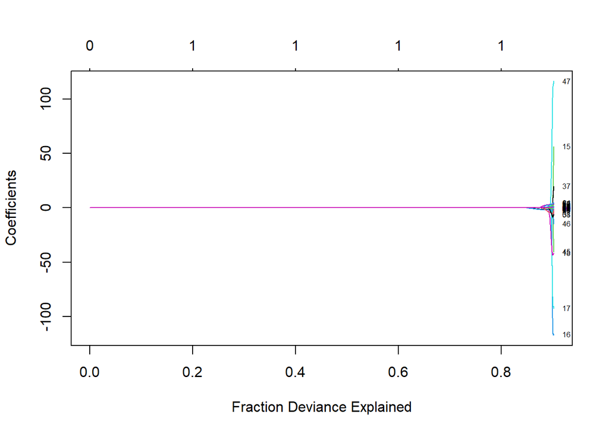

```r
plot(model.2, xvar="dev", label=TRUE)
```

```r
model.2$beta[,1]
```

```
##              pre_death             poorhealth    poorphyshealth_days
##                      0                      0                      0
##    poormenthealth_days                low_bwt             ad_smoking
##                      0                      0                      0
##             ad_obesity          foodenv_index        phys_inactivity
##                      0                      0                      0
##            exer_access           excess_drink         alc_drivdeaths
##                      0                      0                      0
##                    sti             teen_birth              uninsured
##                      0                      0                      0
##      primcareproviders               dentists    menthealthproviders
##                      0                      0                      0
##               prevhosp           mammo_screen               flu_vacc
##                      0                      0                      0
##                 hsgrad            somecollege             unemployed
##                      0                      0                      0
##          child_poverty            income_ineq            sing_parent
##                      0                      0                      0
##           social_assoc          violent_crime          injury_deaths
##                      0                      0                      0
##                 pm_air             water_viol           housing_prob
##                      0                      0                      0
##          driving_alone           long_commute   age_adj_premortality
##                      0                      0                      0
##      freq_physdistress      freq_mentdistress               diabetes
##                      0                      0                      0
##                    hiv          food_insecure ltd_access_healthyfood
##                      0                      0                      0
##         mvcrash_deaths           insuff_sleep       uninsured_adults
##                      0                      0                      0
##        uninsured_child              other_pcp               medhhinc
##                      0                      0                      0
##        freelunch_child             res_seg_bw             res_seg_nw
##                      0                      0                      0
##     firearm_fatalities          homeownership       hous_cost_burden
##                      0                      0                      0
##             population                   bw18                  gte65
##                      0                      0                      0
##           nonhisp_afam     AmerInd_AlasNative                  Asian
##                      0                      0                      0
##           OPacIslander                   Hisp          nonhisp_white
##                      0                      0                      0
##        nonprof_english                 female                  rural
##                      0                      0                      0
```

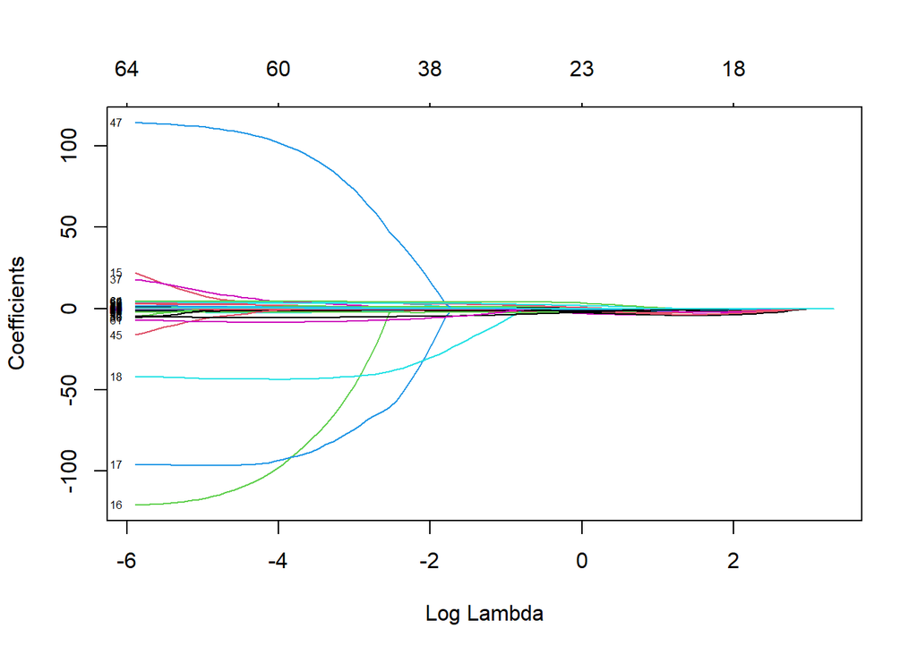

```r
#Elastic Net

model.3<-glmnet(x.train, life.exp.train, alpha=0.1, standardize = TRUE)

plot(model.3, xvar="lambda", label=TRUE)
```

### Step 3: Using cross-validation to select the optimal value for lambda (tuning parameter)

Reminder when lambda is 0, you will obtain OLS regression coefficients (i.e. no regularization) When lambda approaches large numbers, the regression coefficents will shrink toward 0

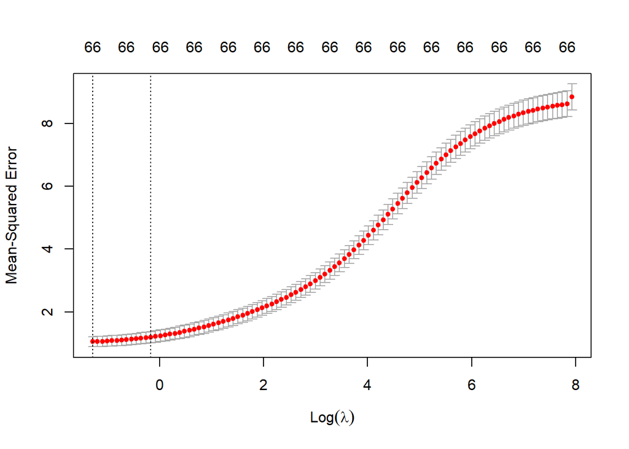

```r
model.1.cv<-cv.glmnet(x.train, life.exp.train, alpha=0)
plot(model.1.cv)
```

```r
model.1.cv$lambda.min
```

```
## [1] 0.2769684
```

```r
model.1.cv$lambda.1se
```

```
## [1] 0.8458214
```

```r
model.1.train.final<-glmnet(x.train, life.exp.train, alpha=0, lambda=model.1.cv$lambda.1se)
coef(model.1.train.final)
```

```
## 67 x 1 sparse Matrix of class "dgCMatrix"
##                                   s0
## (Intercept)             9.069620e+01
## pre_death              -2.856170e-04
## poorhealth              3.065376e-01
## poorphyshealth_days    -2.452931e-02
## poormenthealth_days    -7.841025e-02
## low_bwt                 8.605142e-01
## ad_smoking             -1.545466e+00
## ad_obesity             -1.735830e+00
## foodenv_index          -3.766134e-03
## phys_inactivity        -2.151336e+00
## exer_access             4.392711e-02
## excess_drink            1.984257e-01
## alc_drivdeaths          2.702223e-02
## sti                    -2.320213e-04
## teen_birth             -8.185884e-03
## uninsured               2.156645e-01
## primcareproviders       1.065487e+02
## dentists               -9.719983e+01
## menthealthproviders    -3.445762e+01
## prevhosp               -3.651973e-05
## mammo_screen            3.356053e-01
## flu_vacc               -2.760208e-01
## hsgrad                 -3.032455e-01
## somecollege             5.545075e-01
## unemployed             -1.601314e+00
## child_poverty          -7.413969e-01
## income_ineq             8.382363e-03
## sing_parent            -6.038556e-02
## social_assoc           -5.376549e-03
## violent_crime          -2.449086e-04
## injury_deaths          -1.016226e-02
## pm_air                 -8.526739e-02
## water_viol              3.740194e-02
## housing_prob            4.222813e-01
## driving_alone          -2.557622e+00
## long_commute           -3.272253e-01
## age_adj_premortality   -7.590476e-03
## freq_physdistress       2.750955e-01
```

[output cut: 14 more lines]

```
## firearm_fatalities     -6.407599e-03
## homeownership           1.820547e-01
## hous_cost_burden        7.305884e-01
## population             -4.366545e-09
## bw18                   -4.240986e+00
## gte65                   2.933234e+00
## nonhisp_afam            4.822778e-01
## AmerInd_AlasNative      8.353835e-02
## Asian                   3.300568e+00
## OPacIslander           -5.630505e+00
## Hisp                    4.844325e-01
## nonhisp_white          -5.092671e-01
## nonprof_english         5.189300e+00
## female                 -1.332435e+00
## rural                   3.155518e-01
```

### Step 4: Apply model to test set and evaluate model

```r
model.1.test.pred<-model.1.train.final %>% predict(x.test) %>% as.vector()

data.frame(RMSE=RMSE(model.1.test.pred, life.exp.test), RSQ=R2(model.1.test.pred, life.exp.test))
```

```
##      RMSE       RSQ
## 1 1.11091 0.8544803
```

### Exercise

Using cross-validation, find the optimal values for lambda when using lasso and elastic net, setting the alpha of the elastic net to 0.5. Then apply the final models to the test set. Which model would you choose if this were your study? Why? (Note, again normally we wouldn’t compare models within the test set. We would either have a validation set, or would assess error in the training set.)

### Step 5: Using caret to select best tuning parameters

I will demonstrate how you can use the caret package to construct penalized regressions.By default, caret will vary both alpha and lambda to select the best values via cross-validation. Because the alpha is not set at 0 or 1, this can (and often does) result in an elastic net. But, you can set the alpha level at a fixed value in order to obtain ridge or lasso results.

tuneLength sets the number of combinations of different values of alpha and lambda to compare. 10 values of alpha and 10 values of lambda

```r
set.seed(123)
en.model<- train(
  life_exp ~., data = train.data, method = "glmnet",
  trControl = trainControl("cv", number = 10),
 tuneLength=10
  )
#Print the values of alpha and lambda that gave best prediction
en.model$bestTune
```

```
##    alpha     lambda
## 55   0.6 0.03644533
```

```r
#Print all of the options examined
en.model$results
```

```
##     alpha      lambda      RMSE  Rsquared       MAE    RMSESD RsquaredSD
## 1     0.1 0.001279665 0.9928499 0.8892506 0.5585560 0.1932511 0.03460226
## 2     0.1 0.002956193 0.9927684 0.8892739 0.5584954 0.1932070 0.03457897
## 3     0.1 0.006829189 0.9923001 0.8894012 0.5579635 0.1933353 0.03448504
## 4     0.1 0.015776314 0.9902532 0.8898153 0.5564404 0.1952903 0.03463959
## 5     0.1 0.036445331 0.9867300 0.8904485 0.5527721 0.2002353 0.03525438
## 6     0.1 0.084193445 0.9817545 0.8914752 0.5496360 0.2069650 0.03588305
## 7     0.1 0.194497782 0.9863792 0.8907867 0.5546968 0.2161281 0.03703163
## 8     0.1 0.449315115 1.0186939 0.8856486 0.5849671 0.2280215 0.03949174
## 9     0.1 1.037976217 1.1084165 0.8728589 0.6617052 0.2375589 0.04372544
## 10    0.1 2.397859746 1.3118739 0.8463424 0.8414637 0.2337133 0.05153056
## 11    0.2 0.001279665 0.9929659 0.8892040 0.5586927 0.1936585 0.03473094
## 12    0.2 0.002956193 0.9923100 0.8894090 0.5579257 0.1932048 0.03449066
## 13    0.2 0.006829189 0.9913198 0.8896275 0.5569880 0.1938153 0.03448302
## 14    0.2 0.015776314 0.9883802 0.8901718 0.5537711 0.1971386 0.03490403
```

[output cut: 187 more lines]

```r
# Model coefficients
coef(en.model$finalModel, en.model$bestTune$lambda)
```

```
## 67 x 1 sparse Matrix of class "dgCMatrix"
##                                    1
## (Intercept)             8.996010e+01
## pre_death              -2.705044e-04
## poorhealth              .
## poorphyshealth_days     .
## poormenthealth_days     .
## low_bwt                 1.648604e+00
## ad_smoking              .
## ad_obesity             -1.095288e+00
## foodenv_index           .
## phys_inactivity        -2.616403e-01
## exer_access             .
## excess_drink            .
## alc_drivdeaths          .
## sti                     .
## teen_birth              .
## uninsured               .
## primcareproviders       .
## dentists                .
## menthealthproviders    -2.078831e+01
## prevhosp                .
## mammo_screen           -2.593944e-02
## flu_vacc               -4.034535e-02
## hsgrad                  .
## somecollege             .
## unemployed              .
## child_poverty           .
## income_ineq             4.677286e-02
## sing_parent             .
## social_assoc            .
## violent_crime          -3.327130e-05
## injury_deaths          -2.395108e-03
## pm_air                 -9.639323e-02
## water_viol              .
## housing_prob            .
## driving_alone          -2.221969e+00
## long_commute           -1.385142e-01
## age_adj_premortality   -1.654244e-02
## freq_physdistress       .
```

[output cut: 14 more lines]

```
## firearm_fatalities      .
## homeownership           .
## hous_cost_burden        .
## population              .
## bw18                   -4.495829e+00
## gte65                   1.755908e+00
## nonhisp_afam            .
## AmerInd_AlasNative      .
## Asian                   3.189782e+00
## OPacIslander           -3.960023e+00
## Hisp                    .
## nonhisp_white          -5.949705e-01
## nonprof_english         3.135536e+00
## female                  .
## rural                   1.975465e-01
```

```r
# Make predictions

en.pred <- en.model %>% predict(x.test)

# Model prediction performance
data.frame(
  RMSE = RMSE(en.pred, test.data$life_exp),
  Rsquare = R2(en.pred, test.data$life_exp)
)
```

```
##       RMSE   Rsquare
## 1 1.103606 0.8605858
```

### Exercise:

The following code will allow you to fix the alpha (I have it set to 0 for a ridge) and run either a ridge or lasso analysis. Use that code to run both ridge and Lasso using the caret package and obtain coefficients and evaluation metrics.

If the caret package will select the optimal alpha and lambda value, why might you still choose lasso or ridge over elastic net (or an automated process of choosing alpha as in caret)?

```r
#Create grid to search lambda
lambda<-10^seq(-3,3, length=100)

set.seed(100)

model.4<-train(
  life_exp ~., data=train.data, method="glmnet", trControl=trainControl("cv", number=10), tuneGrid=expand.grid(alpha=0, lambda=lambda)
)
```